# Análisis Manabí de fallecimientos Marzo - Abril 2020

06/05/2020

### Análisis

El siguiente es un análisis realizado en dos contextos (Provincial y cantonal), para los cuales se ha tomado la data de fuentes como el INEC (nacimientos y defunciones) y el msp(Reportes de fallecimientos covid19 marzo y abril). Para cada uno de éstos contextos se hace el siguiente análisis.  
* Cantidad de fallecidos por registro civil enero - abril 2017-2019 (Estimaciones para 2019)  
* Cantidad de fallecidos por registro civil marzo - abril 2017-2019, excluyendo fallecimientos por muertes violentas, accidentes de transito, suicidios ,etc (Estimaciones para 2019)  
* Cantidad de fallecidos por registro civil marzo - abril 2017-2019, excluyendo fallecimientos por muertes violentas, accidentes de transito, suicidios y casos de mortalidid por enfermedades referentes al sistema respiratorio (Estimaciones para 2019)  
* Comparativa entre estos datos de fallecimientos anteriores, el dato de fallecimiento oficial covid19 y el número de registros de fallecimientos del registro civil 2020  
* Proyección de casos usando la cantidad de fallecimientos que resultan de restar los del registro civil con los de registros históricos (Contexto Provincial)  
* Proyección de casos usando la cantidad de fallecimientos que se determinen en el análisis (Contexto Cantonal)  
* Al final, análisis de comparativa entre la densidad poblacional de los cantones, la cantidad de fallecidos oficial de covid19 y la cantidad de fallecidos que resulten del análisis.

### Fallecimientos provincial 2017-2019 Enero - Abril

Datos registrados en el INEC y registro civil para los siguientes años.

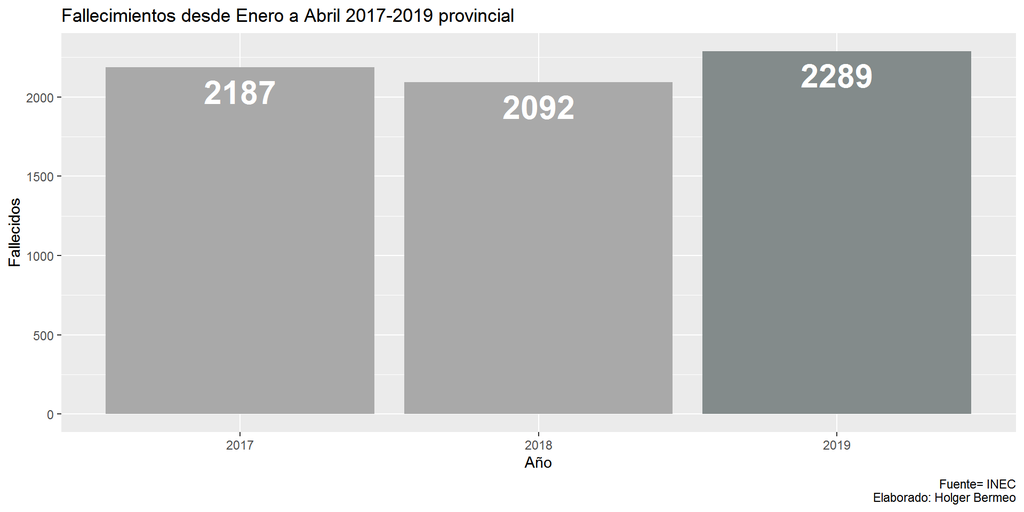

### Fallecimientos provincial 2017-2019 excluyendo fallecimientos por violencia, accidentes tránsito, suicidios, etc

Datos registrados en el INEC y registro civil para los meses de marzo y abril

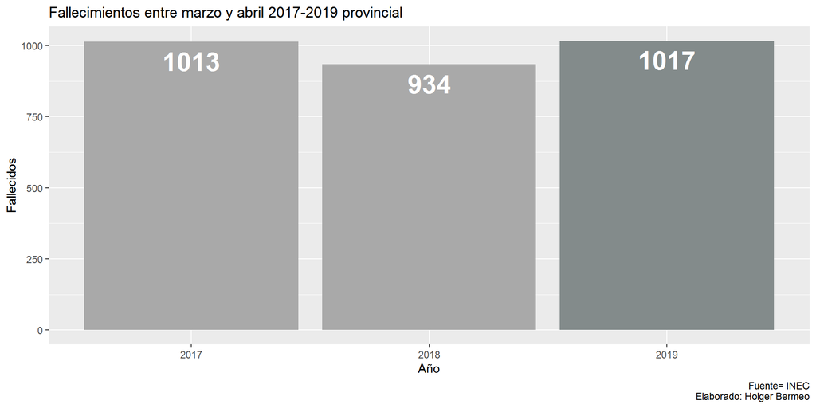

### Fallecimientos provincial 2017-2019 excluyendo fallecimientos por violencia, accidentes tránsito, suicidios, etc y enfermedades asociadas al sistema respirarotorio, neumonías e influenzas.

Datos registrados en el INEC y registro civil para los meses de marzo y abril

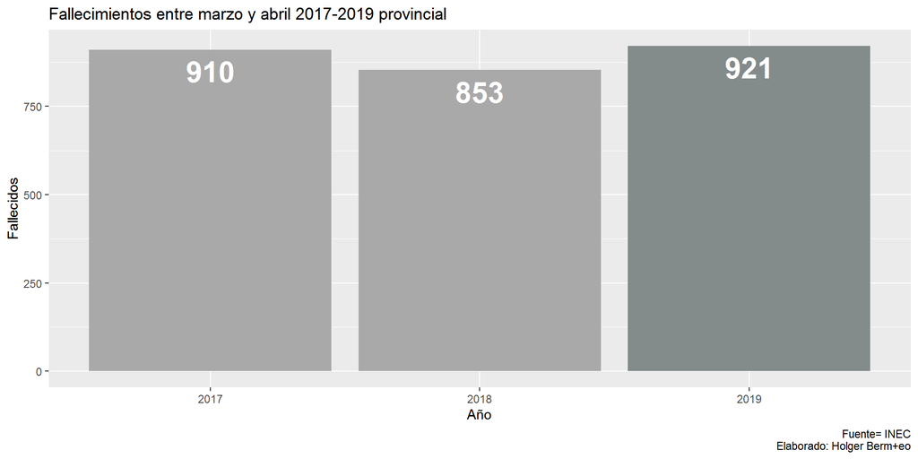

### Comparativa provincial de fallecimientos en los meses de marzo y abril

Datos registrados en el INEC y registro civil para los meses de marzo y abril, y los datos de fallecimientos totales por covid19 en la provincia. Haciendo la diferencia entre los promedios (máximo) fallecidos en años anteriores aislando diferentes casos tenemos el resultado de muertes problables por covid19 que se estarían dando en estos dos meses, llegando a ser cercanos estos valores a los reportados por el msp para muertes confirmadas por covid19 más las muertes con probabilidad de covid19.

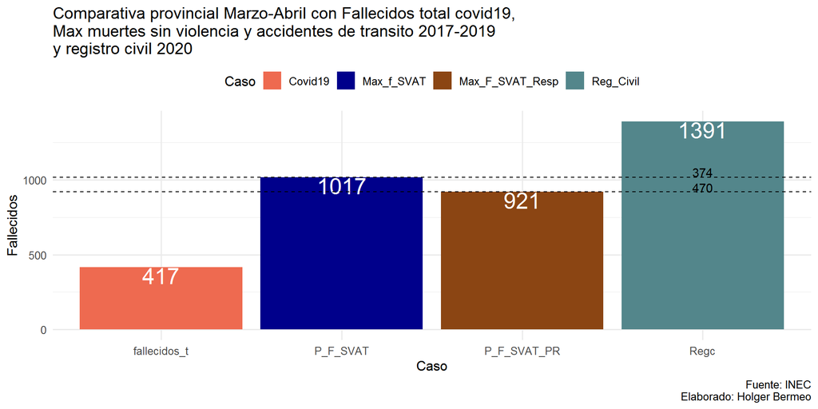

Para el siguiente análisis tomamos los datos del registro civil y descartamos lo que podría ser una cantidad de fallecidos que normalmente fallecen en la provincia excluyendo las muertes por fallecimientos por violencia, accidentes de tránsito, y suicidios, además las enfermedades que tengan que ver con el sistema respiratorio. Teniendo como referencia que la cantidad de fallecidos totales por covid19 están cercanos a estos valores que obtenemos del cálculo anterior.

### Proyección provincial con tasa letalidad nacional e internacional

##### Con cifras que resultan del análiss de fallecidos anterior

Se proyecta la cantidad de fallecidos totales con tasa de letalidad nacional total(9.6%) y la tasa de letalidad internacional (6.9%)  
[Análisis de tasas de letalidad nacional aquí](https://holgerbermeo.github.io/analisis_covid19/)  
proy = n fallecidos  
actual = contagiados oficiales marzo-abril  
tl_96 = Contagiados proyectados con tasa de letalidad nacional  
tl_69 = Contagiados proyectados con tasa de letalidad internacional

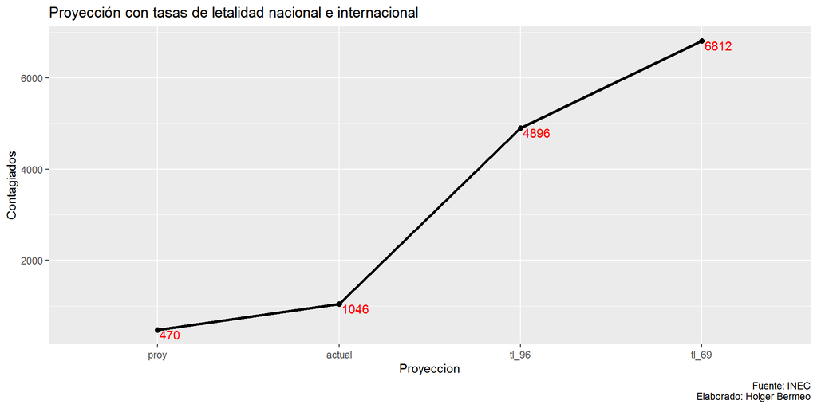

### Fallecimientos cantonales 2017-2019 Enero - Abril

Datos registrados en el INEC y registro civil para los siguientes años, en el 2019 se estiman los valores debido a que no hay desagregación de datos cantonal por el registro civil.

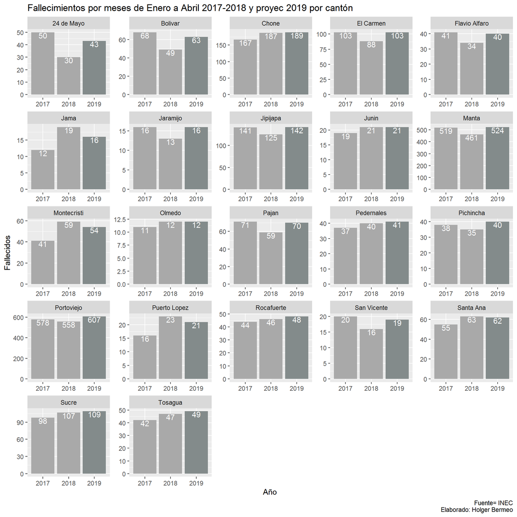

### Fallecimientos cantonales 2017-2019 excluyendo fallecimientos por violencia, accidentes tránsito, suicidios, etc

Datos registrados en el INEC y registro civil para los meses de marzo y abril

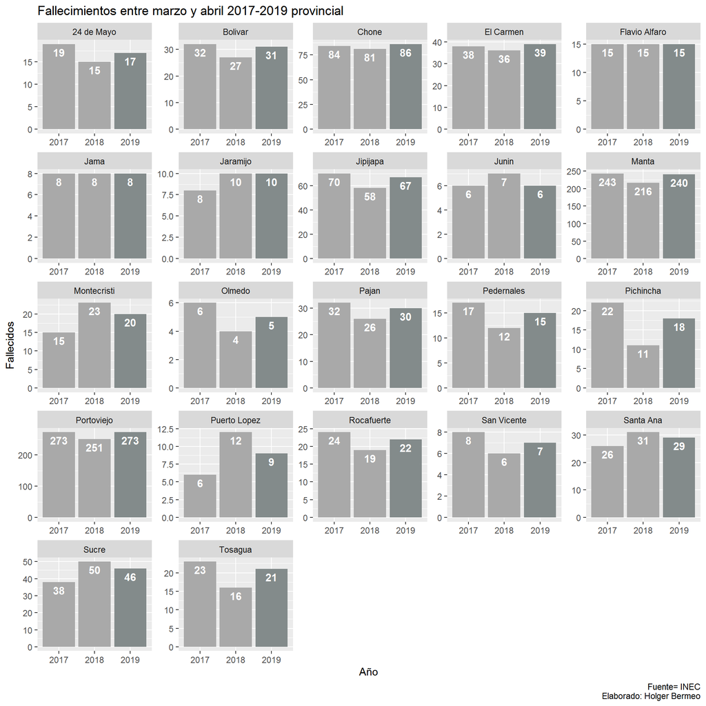

Datos registrados en el INEC y registro civil para los meses de marzo y abril

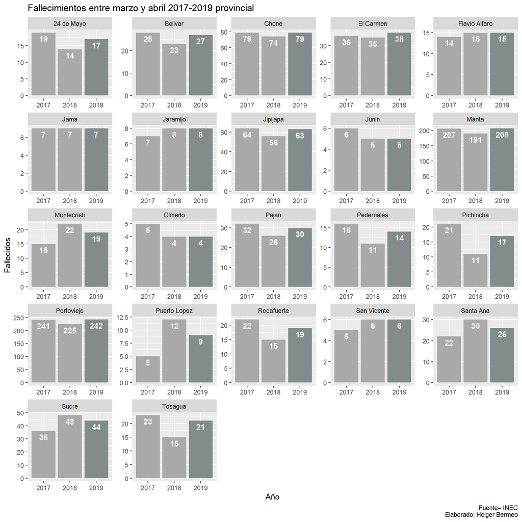

### Comparativa cantonal de fallecimientos en los meses de marzo y abril

Comparativa entre los datos de fallecidos por covid19 marzo-abril 2020, lo promedios máximos históricos de fallecidos y los datos del registro civil(estimaciónes para cada cantón debido a falta de desagregación de información en todo ese período) para cada cantón en esos mismo meses.  
P_F_SVAT = Personas fallecidads sin fallecimientos por violencia, accidente de transito y otras  
P_F_SVAT_PR = Personas fallecidads sin fallecimientos por violencia, accidente de transito, otras y también con problemas respiratorios

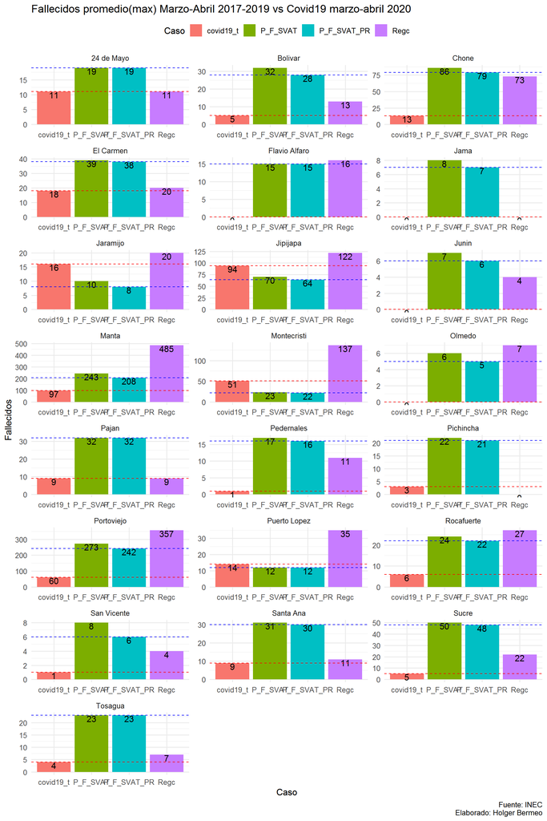

### Datos que se tomará para el análisis de proyección

Para el siguiente análisis tomamos la cantidad de fallecidos de cada cantón haciendo un análisis por cada uno de ellos.  
* En los cantones que la cantidad de fallecidos por el registro civil estén dentro de los valores normales por los históricos, se tomará la cifra oficial de fallecidos por covid19.  
* En los cantones donde los datos del registro civil esten por arriba de los datos oficiales de fallecidos por covid19 y por arriba de los datos históricos para ese cantón, se coloca la cifra del registro civil menos la cifra del histórico.  
* Y para cuando la cifra del registro civil sea mayor a la del registro oficial de fallecidos por covid19 y mayor a la del histórico para el cantón, se coloca la cifra del registro civil.

### Proyección por cantones con tasa letalidad nacional e internacional

##### Con cifras oficiales de fallecidos que se difieren del análisis anterior

Se proyecta la cantidad de fallecidos totales con tasa de letalidad nacional total(9.6%) y la tasa de letalidad internacional (6.9%)  
[Análisis de tasas de letalidad nacional aquí](https://holgerbermeo.github.io/analisis_covid19/)  
proy = n fallecidos  
actual = contagiados oficiales marzo-abril  
tl_96 = Contagiados proyectados con tasa de letalidad nacional  
tl_69 = Contagiados proyectados con tasa de letalidad internacional

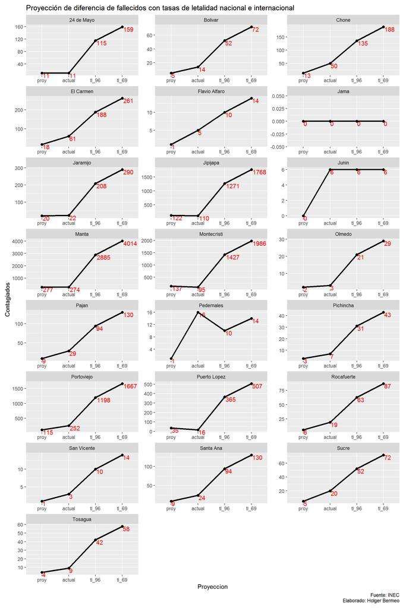

### Análisis comparativo densidad poblacional, fallecidos covid19, fallecidos producto del análisis anterior

Análisis comparativo entre la distribución de los cantones por la cantidad de población por km y los fallecidos covid19 por cada 10 mil habitantes.

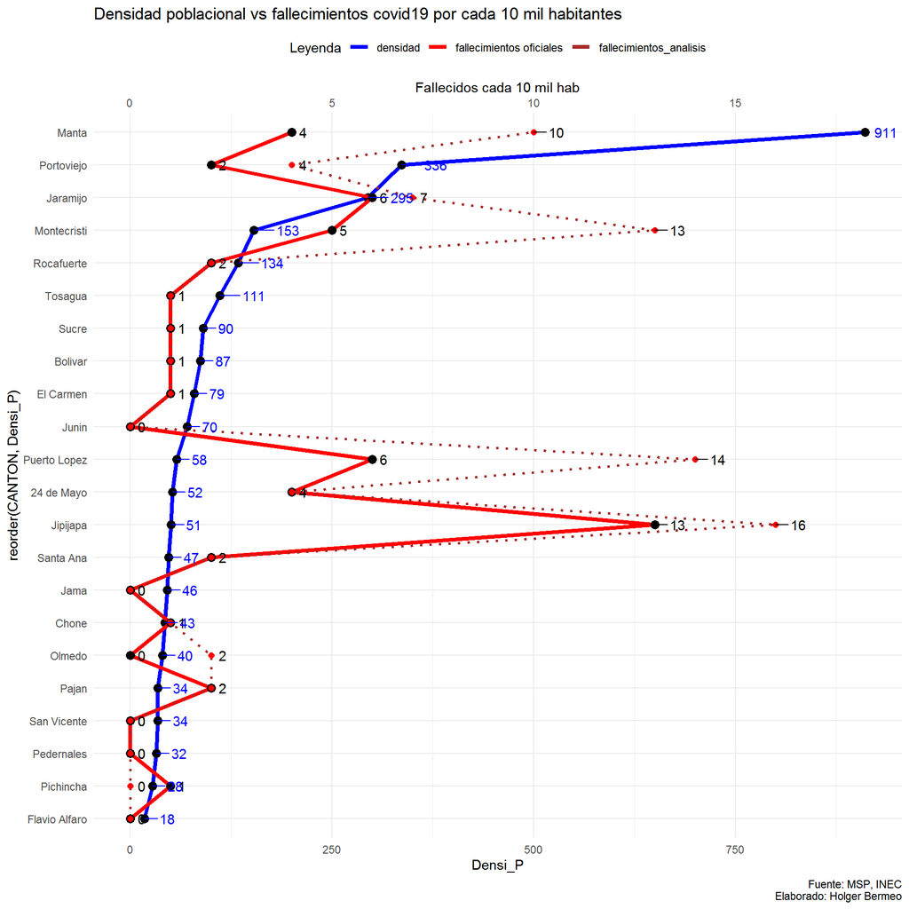

### Conclusiones.

Si bien es cierto que en el análisis provincial nos dá una aproximación muy cercana de la cantidad de fallecidos con las cifras oficiales, en el análisis cantonal evidenciamos una realidad diferente para cada uno de ellos.  
Existen cantones que si bien es cierto han confirmado casos de fallecimientos por covid19 la cantidad de fallecidos por registro civil es menor que incluso el histórico para dicho cantón. En cambio otros alertan una grave situación en cuanto que el registro por muertes en el registro civil supera a la oficial del covid19 e incluso al histórico como por ejem: Jaramijó, Jipijapa, Manta, Montecristi, Portoviejo y Puerto López.  
Esta divergencia entre cantones que registran menos muertes que incluso los histórico y otros que sobrepasan incluso las muertes oficiales, quizás puedan estar dado ya sea por la estimación de data (registro civil no desagrega por completo la información a cantón) o porque en la realidad existe el traslado de contagiados entre cantones que poseen mejores equipamientos en cuanto a salud y allí registran el deceso como por ejem casos en Manta que superan en doble al histórico.

Arq. Holger Bermeo Cantos